In an effort to better understand the spread of diseases like COVID-19, I built a simulation model that tries to create a semi-realistic agent-based simulation for the spread of disesases. it relies on a SIHRD model (Susceptible, Infected, Hospitalized, Recovered, Dead). It takes in a number of custom paramters that you can alter in the accompanying shiny app to see how they impact disease growth/spread. These variables include:

- **N**: Population Size
- **Baseline** Rate: Percentage of population infected originally
- **Infection Radius**: The distance that you need to come within an infected person to run chance of becoming infected.
- **InfectionRate**: The probability you become infected if you are exposed to an infected person
- **InfectionDays**: The average number of days the infection lasts.
- **InfectionDaysSD**: The standard deviation for distribution of infection length.
- **SideLength**: Each “city” is a square with this side length
- **MoveSD**: Standard deviation of normal distribution centered at 0 that generates agent movement in the space each day.
- **NumDays**: Number of days in the simulation
- **CityPopShareShape1**, **CityPopShareShape2**: City population shares of N are determined by a beta distribution determined by these parameters.
- **Community Centers**: The number of local gathering places in each city
- **CommCenterRate**: The probability that a person visits the community center rather than their typical random movement each day.
- **CityMoveRate**: The probablity that a person moves to another random city on a given day.
- **HospitalBaseline**: The number of hospital beds in the simulation
- **MortalityBaseline**: Baseline mortality rate for the disease when not in the hospital
- **MortalityFullHospitals**: Mortality rate for the disease when hospitals are full
- **HospitalMinDays**: The minimum number of days that must have passed before someone can be severe enough to be admitted to the hospital.
- **MortalityMinDays**: The minimum number of days that must have passed before someone can be severe enough to die from disease.

Using the shiny app, we can generate plots like these that show how many people the disease can impact. The horizontal dotted line is the number of hospital beds in the system.

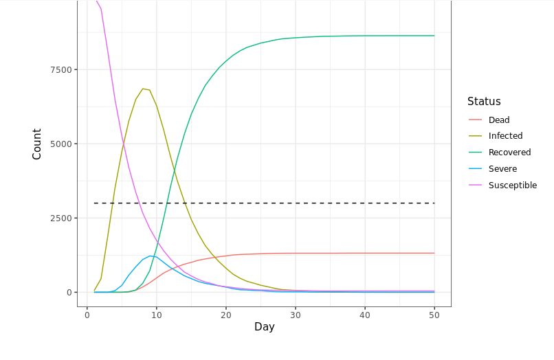

We can also run simulations that include multiple cities:

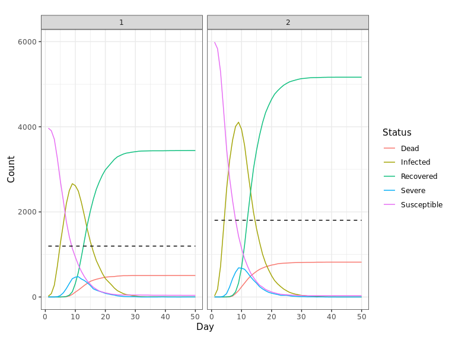